# Diamond sizes

Published

September 12, 2022

We have data about 53940 diamonds. Only 126 are larger than 2.5 carats. The distribution of the remainder is shown below:

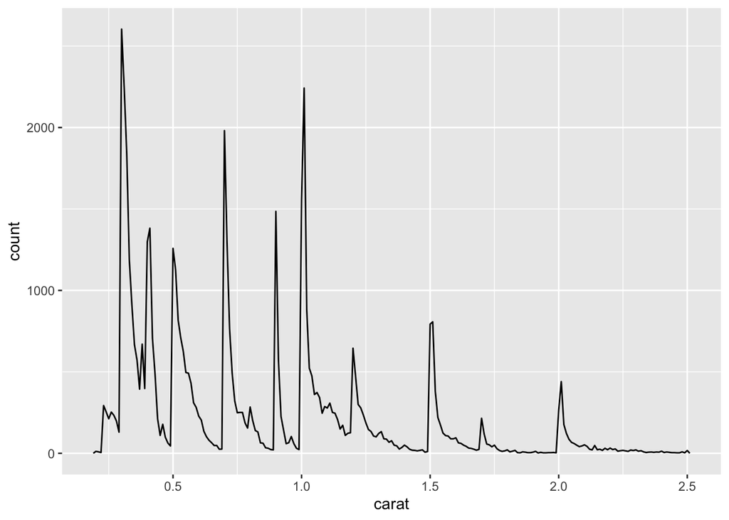

## Describe the most striking features of frequency polygon

Looks like its connecting each bin

# Exercise #4

> Create a document in a Google doc or MS Word (or locate a document you have created previously) with some content in it such as headings, hyperlinks, formatted text, etc. Copy the contents of this document and paste it into a Quarto document in the visual editor. Then, switch over to the source editor and inspect the source code.

**Abstract**

**Title of dissertation:** Progression, Prognostic Factors, and Economic Costs of Loss of Independence in Parkinson Disease

Tsung-Ying Lee, Doctor of Philosophy, 2024

**Dissertation directed by:** Eberechukwu Onukwugha, PhD

Professor

Executive Director of Pharmaceutical Research Computing

Department of Practice, Sciences, and Health Outcomes Research

**Introduction:** Parkinson disease (PD) is a neurodegenerative disorder causing disability and loss of independence (LOI), impacting patients and families. The longitudinal patterns of LOI in PD, prognostic factors predicting LOI in different types of activities of daily living (ADLs), and costs associated with functional dependency (FD) in PD remain unclear.

**Methods:** We used 2003-2020 data from a prospective PD cohort at a tertiary neurologic center. Disability with LOI was assessed using the modified Older Americans Resource and Services Daily Function Questionnaire at baseline and follow-up. Patterns of LOI were summarized using EventFlow data visualization software. Cox proportional hazards models identified prognostic factors for LOI on different types of ADLs. Costs borne by patients with PD (PWP) and their families were analyzed using 2018-2019 Financial and Social Impact of Parkinson’s Disease Survey data. We estimated the incremental costs comparing families of PWP with and without FD using generalized linear models.

**Conclusion:** This study provides novel information about LOI patterns in PD and the fluctuations in patients’ functioning in daily tasks. We identified factors (e.g., dyskinesia and gait impairment) with varying impacts on BADLs and IADLs. The study quantifies the financial strain on families of PWP with FD, underscoring the need for interventions to delay or prevent LOI in PD.